# Differential Expression Analysis by DESeq2: RNA-seq workshop at 21st Century Mouse Genetics 2016

Narayanan Raghupathy, The Jackson Laboratory

August 11, 2016

One of the most common applications of RNA-seq technology is using it for identifying genes that are differentially expressed between sample groups. Typical examples include differential expression analysis between wild type and mutant samples, or cancer vs normal samples.

Let us assume that we have quantified total gene expression for all known genes using RNA-seq analysis pipeline discussed earlier for Diversity Outbred mouse populations under different diets.

We will be using read counts at gene level and the software tool **DESeq2** for doing differential expression analysis on a subset of the DO mice.

Our goals of this exercise are

- find the genes that are differentially expressed between DO mice under standard **Chow diet** and **High fat diet**
- see the **effect of sample size** on detecting differentially expressed genes.

## R Libraries and Data Import

Let us load the R packages and the data needed for the differential expression analysis.

```r
library(DESeq2)
library(ggplot2)
library(dplyr)
```

Let us load the R object file containing all the data we need.

```r
load("data/DO192_DataforSysGenCourse.rdata")
exp.all = read.table("data/expected_read_counts_gene_level.txt", header=T)
```

Let us check the expression data and make it a matrix.

```r
geneIDs = exp.all[,1]
exp.all=exp.all[,-1]
rownames(exp.all)=geneIDs
exp.all[1:5,1:5]
```

Let us create data frame containing key experimental design factors for the experiment.

```r
exp_design = data.frame(mouseIDs=colnames(exp.all),
                        diet=covariates.rna.192$Diet,
                        sex=covariates.rna.192$Sex,
                        coat_color=covariates.rna.192$Coat.Color)
```

```r
all(colnames(exp.all)==exp_design$mouseIDs)
```

## A quick check for sample mixup

Let us do a quick sample mixup check using **Xist** gene expression. Xist is non-coding RNA

```r
geneID="ENSMUSG00000086503"
geneName="Xist"
gIndex = which(rownames(exp.all)==geneID)
data= data.frame(exp_design,
                 exp=as.numeric(exp.all[gIndex,]))
```

```r
head(data)
```

```
##   mouseIDs diet sex coat_color      exp
## 1     F326 chow   F      black 12508.01
## 2     F327 chow   F      black 15085.06
## 3     F328 chow   F      white 13682.44
## 4     F329 chow   F     agouti 16407.37
## 5     F330 chow   F     agouti 17922.90
## 6     F331 chow   F      black 20613.68
```

Let us plot **Xist** expression in all samples against sex.

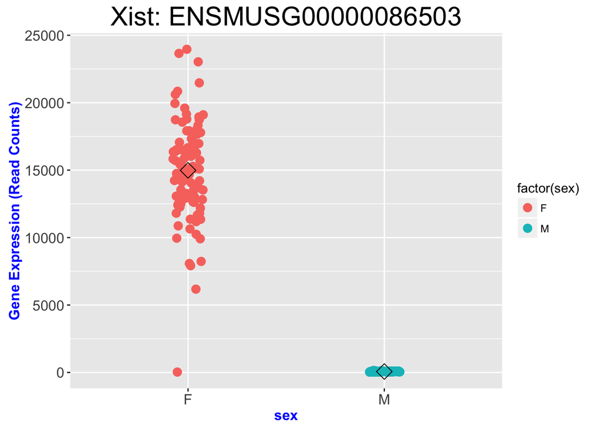

```r
p <- ggplot(data,aes(x=sex,y=exp))
p <- p + geom_point(position = position_jitter(width = 0.2),size=3,
                    aes(colour = factor(sex)))
p <- p + stat_summary(fun.y=mean, geom="point", shape=5, size=4)
p <- p + ylab("Gene Expression (Read Counts)")
p <- p + theme(axis.text=element_text(size=12),
               axis.title=element_text(size=12,face="bold", colour = "blue"),
               plot.title = element_text(size = rel(2)))
p <- p + ggtitle("Xist: ENSMUSG00000086503")
p
```

Let us start with an example identifying the genes that are differentially expressed between two diets **Chow** and **High fat**.

```r
male_index = which(exp_design$sex=="M")
female_index = which(exp_design$sex=="F")
chow_index= which(exp_design$diet=="chow")
hf_index= which(exp_design$diet=="HF")
male_chow = intersect(male_index,chow_index)
male_hf = intersect(male_index,hf_index)
```

## Differential Expression Analysis with **three** samples in each group

To make the example simple, let us subset our expression data such that we have **3 DO mice** under **Chow diet** and 3 DO mice under **High Fat diet**.

```r
sampleSize = 3
```

Later on we will see the effect of sample size by changing it to **10**.

```r
diet_DE = c(male_chow[1:sampleSize],male_hf[1:sampleSize])
exp_design_diet_DE= exp_design[diet_DE,]
head(exp_design_diet_DE)
```

```
##     mouseIDs diet sex coat_color
## 99      M326 chow   M      black
## 100     M327 chow   M     agouti
## 101     M328 chow   M     agouti
## 122     M351   HF   M      black
## 123     M352   HF   M      black
## 124     M353   HF   M     agouti
```

```r
exp_diet_DE=exp.all[,diet_DE]
all(colnames(exp_diet_DE)==as.vector(exp_design_diet_DE$mouseIDs))
```

```
## [1] TRUE
```

```r
head(exp_diet_DE)
```

```
##                     M326  M327        M328  M351  M352         M353
## ENSMUSG00000000001  1511  1816  1432.00000  1099  1310  1119.000000
## ENSMUSG00000000003     0     0     0.00000     0     0     0.000000
## ENSMUSG00000000028    17    30    16.52107    18    26    28.000000
## ENSMUSG00000000031     0     9     2.00000    19     3    92.000000
## ENSMUSG00000000037     0     0     0.00000     0     0     5.999999
## ENSMUSG00000000049 37124 38122 28530.00000 24052 21610 32220.000000
```

Let us filter out genes with zero and low expression (less than 5 read counts) in 50% of the samples.

```r
thres= 5
nzIndex= as.vector(which(apply(exp_diet_DE,1,function(x){sum(x>thres)/length(x)})>=0.5))
head(nzIndex)
exp.dietDE = exp_diet_DE[nzIndex,]
dim(exp.dietDE)
```

## Differential expression analysis with DESeq2

Let us create data frames for **DESeq2** object

```r
### colData contains the condition/group information for Differenetial expression analysis
colData <- DataFrame(group = factor(exp_design_diet_DE$diet))
```

```r
### Create DESeq2 object using expression and colData
dds_3reps <- DESeqDataSetFromMatrix(countData = as.data.frame(round(exp.dietDE)),
         colData = colData, design = ~ group)
dds_3reps <- DESeq(dds_3reps)
res_3reps = results(dds_3reps)
resOrdered_3reps <- res_3reps[order(res_3reps$padj),]
head(resOrdered_3reps)
```

## DE Analysis summary with **3** samples per group

```r
### summary of Differential Expression analysis
summary(res_3reps)
```

```
##
## out of 14689 with nonzero total read count
## adjusted p-value < 0.1
## LFC > 0 (up)     : 261, 1.8%
## LFC < 0 (down)   : 181, 1.2%
## outliers [1]     : 64, 0.44%
## low counts [2]   : 1424, 9.7%
## (mean count < 10)
## [1] see 'cooksCutoff' argument of ?results
## [2] see 'independentFiltering' argument of ?results
```

### P-value histogram

Let us plot the histogram of p-values. The p-value histogram is a good diagnostic test for the differential expression analysis.

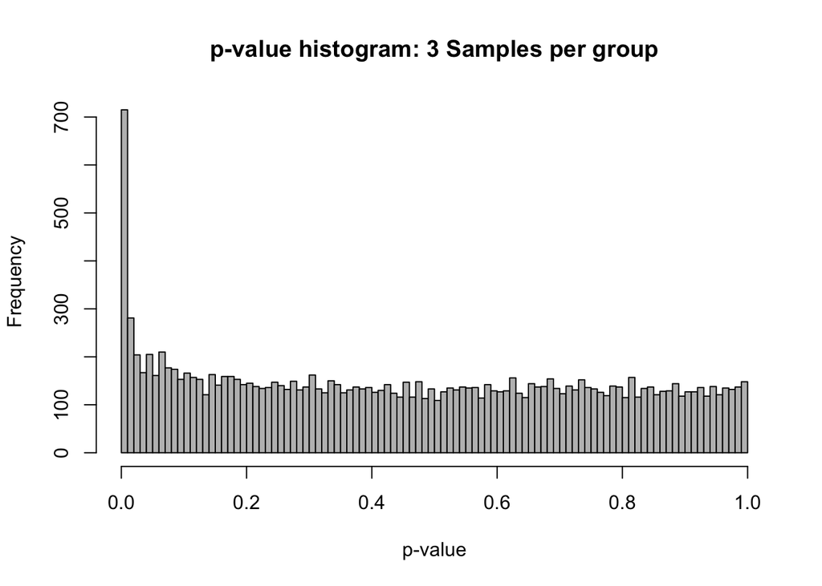

```r
hist(res_3reps$pvalue,breaks=100,col="grey", xlab="p-value",main="p-value histogram: 3 Samples per group")
```

### Top **5** differentially expressed genes

```r
### helper functions to get gene information for a gene
get_gene_name<-function(ensID,gene_df){
  g_ind = which(as.vector(gene_df[,1])==ensID)
  g_name = gene_df[g_ind,2]
  return(g_name)
}
get_gene_info<-function(ensID,gene_df){
  g_ind = which(as.vector(gene_df[,1])==ensID)
  print(g_ind)
  ensID= as.vector(gene_df[g_ind,1])
  gName= as.vector(gene_df[g_ind,2])
  chro = as.vector(gene_df[g_ind,3])
  start = as.vector(gene_df[g_ind,5])
  end = as.vector(gene_df[g_ind,6])
  g_name = paste0(ensID,": ",gName," Chr",chro,"-",start,":",end)
  g_name = paste0(ensID,": ",gName," Chr",chro)
  return(g_name)
}
```

```r
#par(mfrow=c(2,3),las=1)
top5_genes= rownames(resOrdered_3reps[1:5,])
gene_info=read.csv(url("ftp://ftp.jax.org/dgatti/ShortCourse2015/ENSMUSG-gene-info-R84.tsv"),header=FALSE,sep="\t")
print(head(gene_info))
```

```
##                   V1    V2 V3 V4        V5        V6
## 1 ENSMUSG00000000001 Gnai3  3  - 108107280 108146146
## 2 ENSMUSG00000000003  Pbsn  X  -  77837901  77853623
## 3 ENSMUSG00000000028 Cdc45 16  -  18780447  18811987
## 4 ENSMUSG00000000031   H19  7  - 142575529 142578143
## 5 ENSMUSG00000000037 Scml2  X  + 161117193 161258213
## 6 ENSMUSG00000000049  Apoh 11  + 108343354 108414396
```

```
## [1] 8650
```

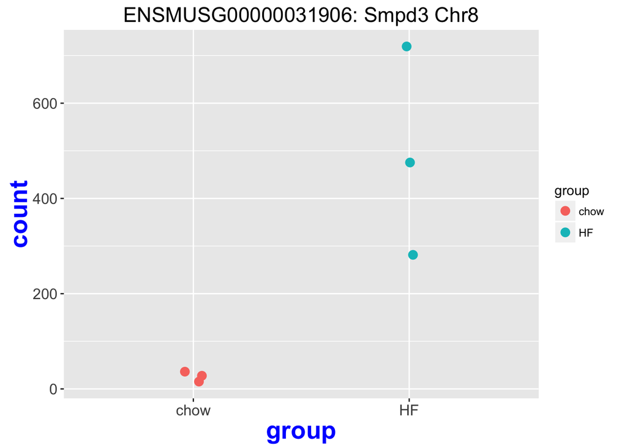

```
## [1] 20690
```

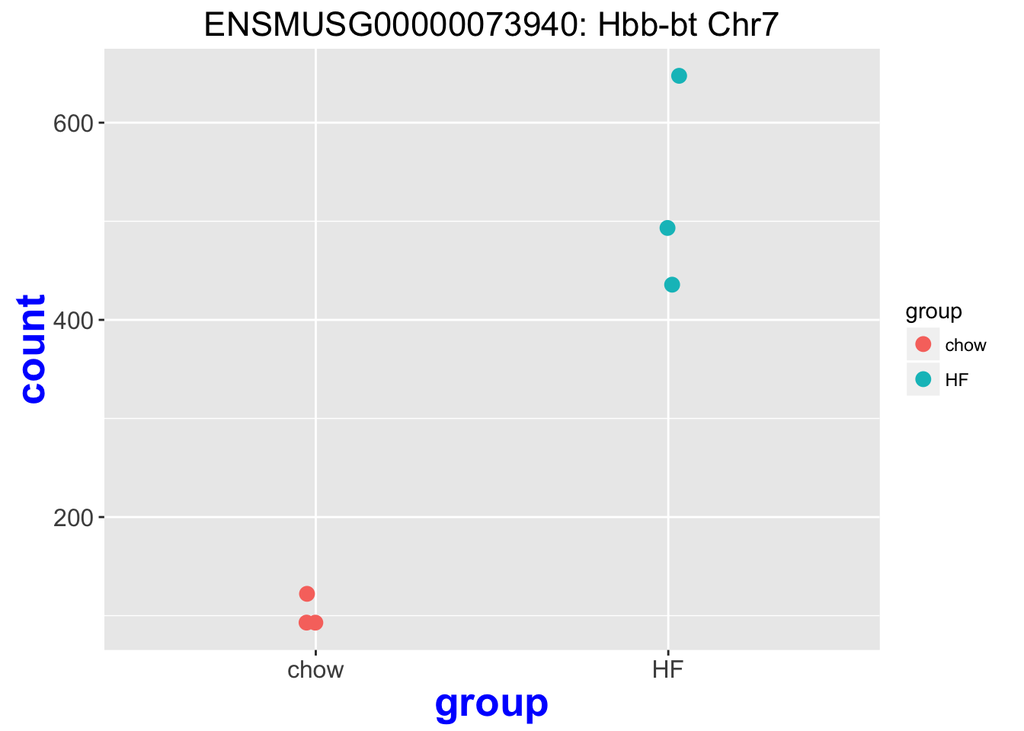

```
## [1] 19342
```

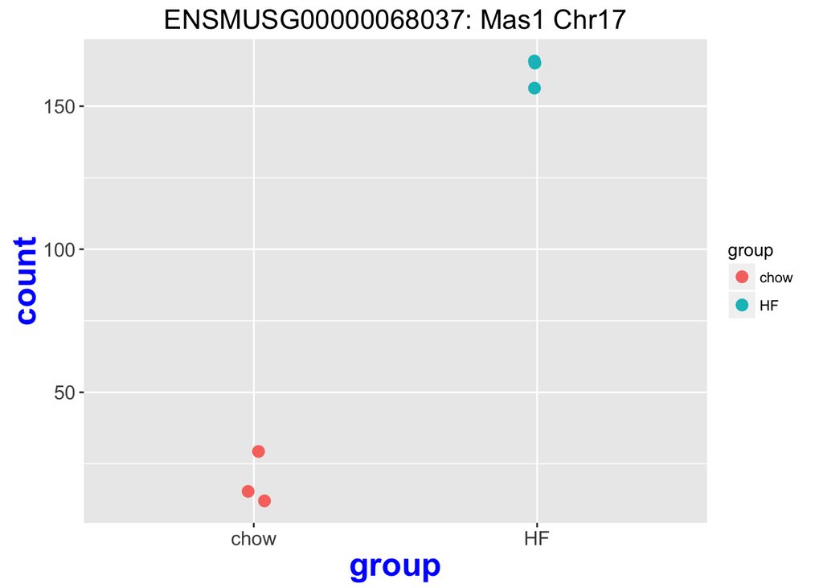

```
## [1] 20041
```

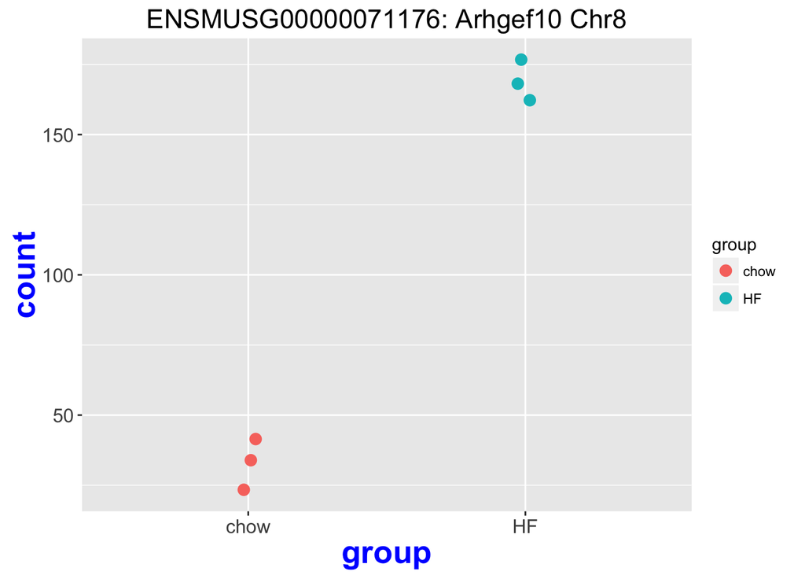

```
## [1] 816
```

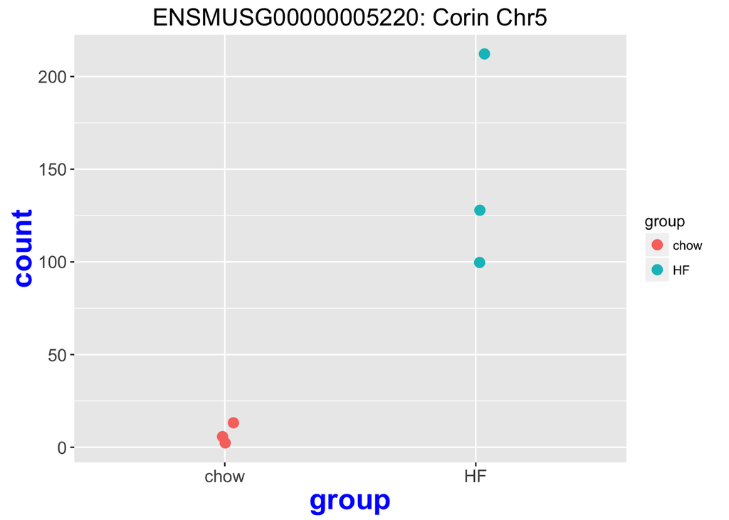

```r
for (i in 1:length(top5_genes)){
  g_id = top5_genes[i]
  g_name = get_gene_name(g_id,gene_info)
  g_info = get_gene_info(g_id,gene_info)
  data <- plotCounts(dds_3reps, gene=g_id, intgroup=c("group"), returnData=TRUE)
  p <- ggplot(data, aes(x=group, y=count, color=group))
  p <- p+ ggtitle(g_info)
  p <- p+ geom_point(position=position_jitter(width=.1,height=0), size=3)
  p <- p + theme(axis.text=element_text(size=12),axis.title=element_text(size=20,face="bold", colour = "blue"),  plot.title = element_text(size =rel(1.5)))
  print(p)
}
```

## Differential Expression Analysis with **ten** samples in each **diet** group

```r
sampleSize = 10
diet_DE = c(male_chow[1:sampleSize],male_hf[1:sampleSize])
exp_design_diet_DE= exp_design[diet_DE,]
head(exp_design_diet_DE)
exp_diet_DE=exp.all[,diet_DE]
all(colnames(exp_diet_DE)==as.vector(exp_design_diet_DE$mouseIDs))
head(exp_diet_DE)
```

Let us filter out genes with zero and low expression (less than 5 read counts) in 50% of the samples.

```r
thres= 5
nzIndex= as.vector(which(apply(exp_diet_DE,1,function(x){sum(x>thres)/length(x)})>=0.5))
head(nzIndex)
exp.dietDE = exp_diet_DE[nzIndex,]
dim(exp.dietDE)
```

Let us create data frames for DESeq2 object

```r
### colData contains the condition/group information for Differenetial expression analysis
colData <- DataFrame(group = factor(exp_design_diet_DE$diet))
```

```r
### Create DESeq2 object using expression and colData
dds_10reps <- DESeqDataSetFromMatrix(countData = as.data.frame(round(exp.dietDE)),
         colData = colData, design = ~ group)
dds_10reps <- DESeq(dds_10reps)
res_10reps = results(dds_10reps)
resOrdered_10reps <- res_10reps[order(res_10reps$padj),]
head(resOrdered_10reps)
```

## DE Analysis summary with **10** and **3** samples per group

```r
### summary of Differential Expression analysis
summary(res_10reps)
```

```
##
## out of 14456 with nonzero total read count
## adjusted p-value < 0.1
## LFC > 0 (up)     : 716, 5%
## LFC < 0 (down)   : 615, 4.3%
## outliers [1]     : 0, 0%
## low counts [2]   : 561, 3.9%
## (mean count < 7)
## [1] see 'cooksCutoff' argument of ?results
## [2] see 'independentFiltering' argument of ?results
```

```r
summary(res_3reps)
```

```
##
## out of 14689 with nonzero total read count
## adjusted p-value < 0.1
## LFC > 0 (up)     : 261, 1.8%
## LFC < 0 (down)   : 181, 1.2%
## outliers [1]     : 64, 0.44%
## low counts [2]   : 1424, 9.7%
## (mean count < 10)
## [1] see 'cooksCutoff' argument of ?results
## [2] see 'independentFiltering' argument of ?results
```

## P-value histogram comparison

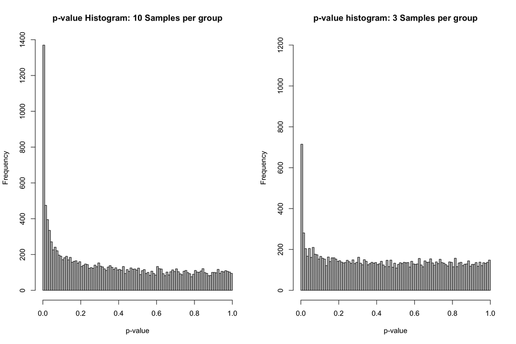

```r
par(mfrow=c(1,2))
hist(res_10reps$pvalue,breaks=100,col="grey", xlab="p-value",main="p-value Histogram: 10 Samples per group")
hist(res_3reps$pvalue,breaks=100,ylim=c(0,1200),col="grey", xlab="p-value",main="p-value histogram: 3 Samples per group")
```

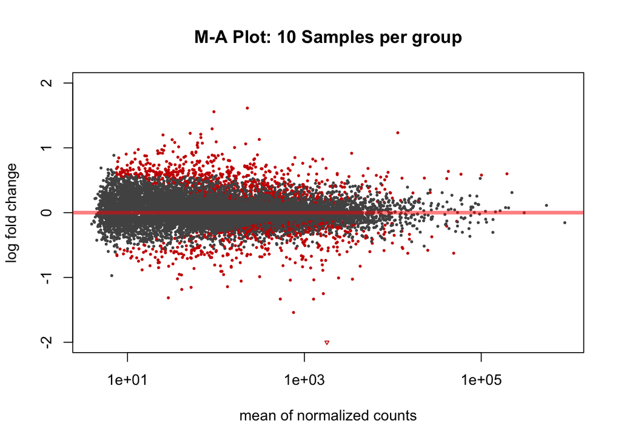

```r
plotMA(res_10reps, main="M-A Plot: 10 Samples per group", ylim=c(-2,2))
```

```
## [1] 4042
```

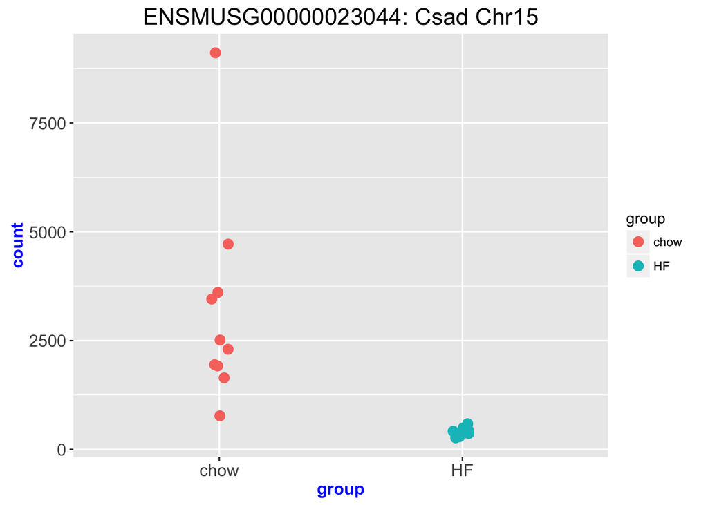

```
## [1] 9036
```

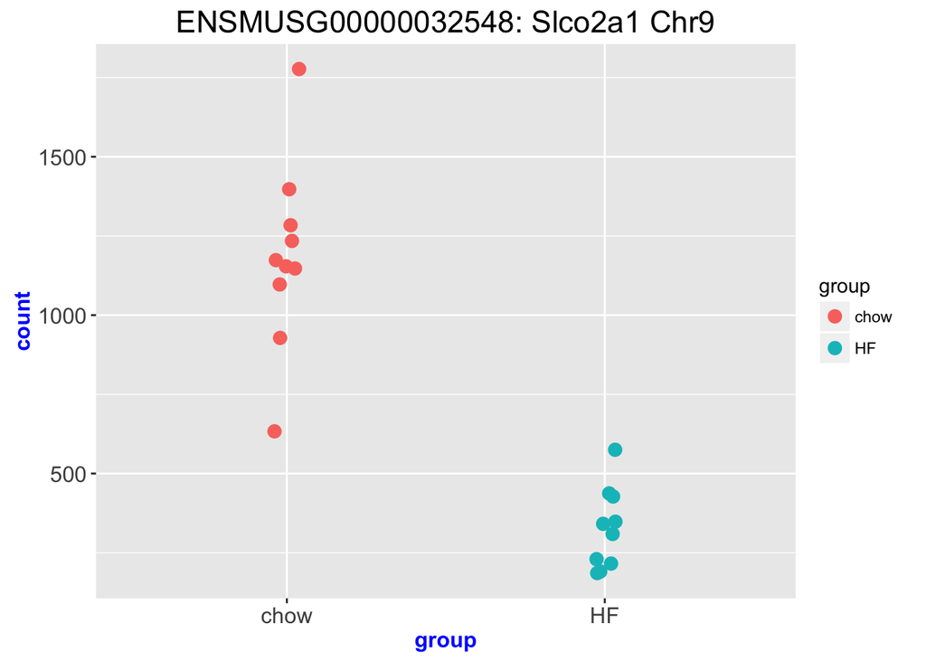

```
## [1] 8955
```

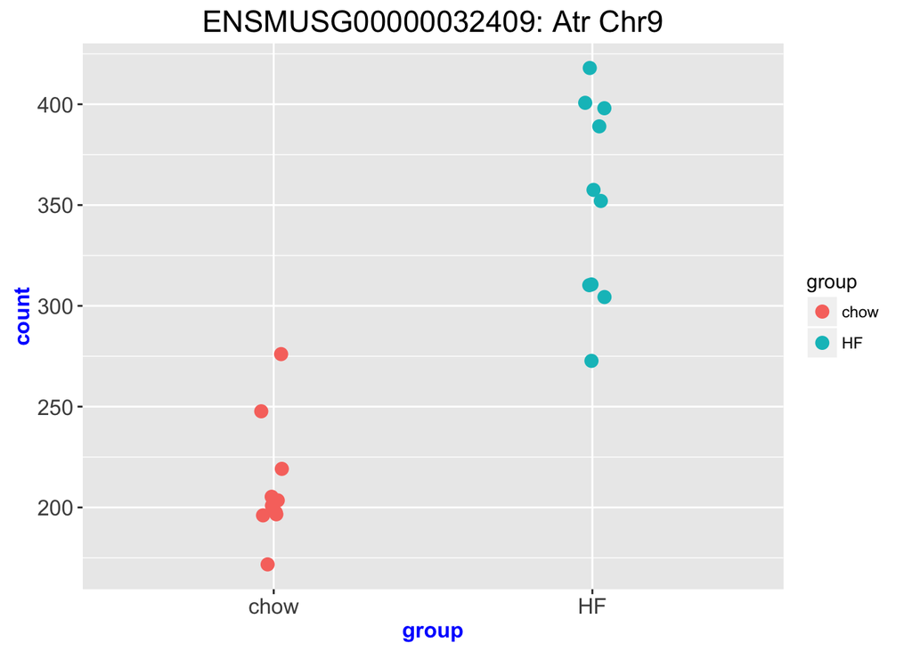

```
## [1] 14259
```

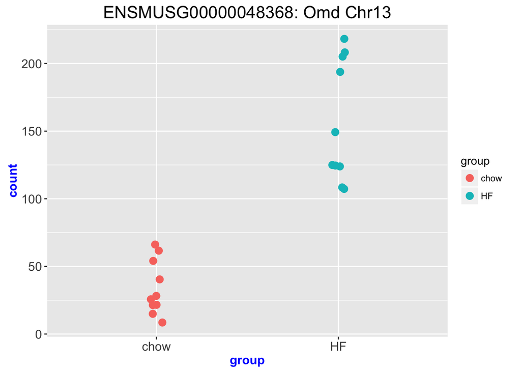

```
## [1] 8650
```

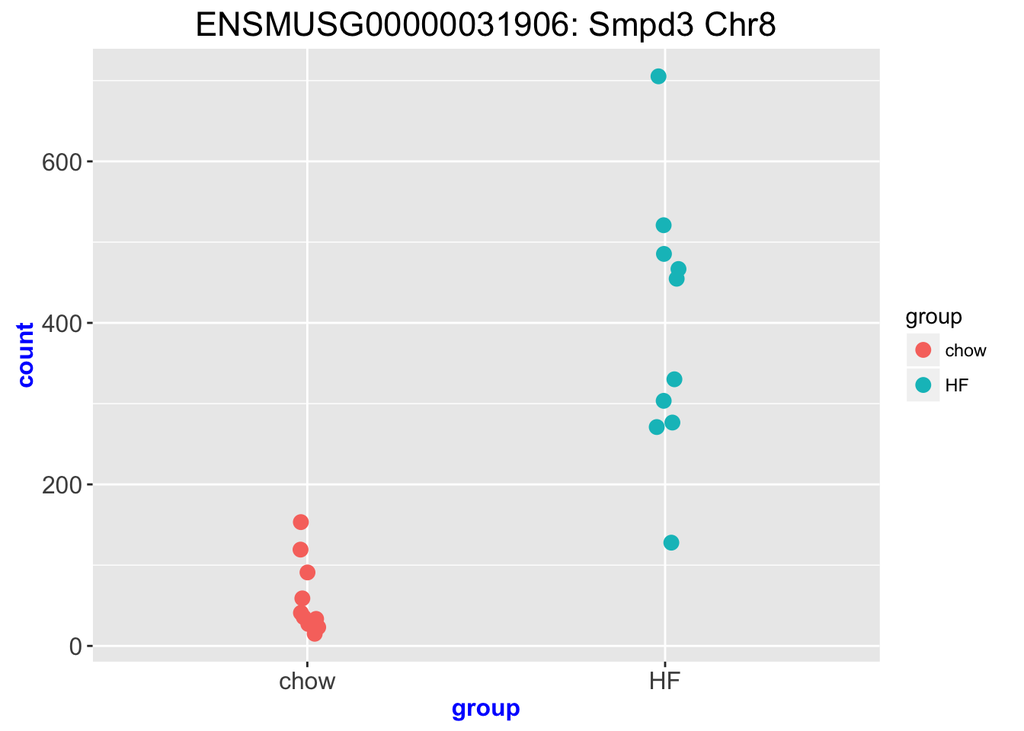

```r
top5_genes= rownames(resOrdered_10reps[1:5,])
par(mfrow=c(2,3),las=1)
for (i in 1:length(top5_genes)){
  g_id = top5_genes[i]
  g_name = get_gene_name(g_id,gene_info)
  g_info = get_gene_info(g_id,gene_info)
  data <- plotCounts(dds_10reps, gene=g_id, intgroup=c("group"), returnData=TRUE)
  p <- ggplot(data, aes(x=group, y=count, color=group))
  p <- p+ ggtitle(g_info)
  p <- p+ geom_point(position=position_jitter(width=.1,height=0), size=3)
  p <- p + theme(axis.text=element_text(size=12),axis.title=element_text(size=12,face="bold", colour = "blue"),  plot.title = element_text(size =rel(1.5)))
  print(p)
}
```